# Rendu 1

DODZRO Darryl Junior Koffi, FOTIO NGNINLAJUNG Francky, HU Xinyu, NOUGWA KEMAJOU Tatiana

2026-04-20

# Introduction

## 1. Données

Le jeu de données étudié porte sur les matchs de Premier League anglaise et couvre plusieurs saisons (de 1993 à 2022). Il est fourni au format **CSV** et contient **11 113 observations** (matchs) et **23 variables**.

Chaque observation correspond à un match et regroupe des informations détaillées sur :

- **L’identité du match** : Saison, date, équipes à domicile (`HomeTeam`) et à l’extérieur (`AwayTeam`).
- **Les scores** : Buts à la mi-temps (`HTHG`, `HTAG`) et au coup de sifflet final (`FTHG`, `FTAG`).
- **Les statistiques de jeu** : Nombre de tirs (`HS`, `AS`), tirs cadrés (`HST`, `AST`), fautes commises (`HF`, `AF`), corners (`HC`, `AC`) et l’identité de l’arbitre (`Referee`).
- **La discipline** : Cartons jaunes (`HY`, `AY`) et cartons rouges (`HR`, `AR`).

Le dataset est structuré de manière à permettre une analyse comparative entre les performances à domicile et à l’extérieur, ainsi qu’une étude de l’évolution des statistiques de jeu sur près de trois décennies.

## 2. Plan d’analyse

Notre démarche d’analyse suit le cycle **Aquire > Filter > Mine > Refine** afin de transformer les données brutes en informations exploitables :

1. **Aquire & Filter (Traitement avec dplyr)** : Nettoyage des données, gestion des valeurs manquantes (`NA`) et création de variables calculées (comme le total de buts ou le cumul des cartons) pour garantir la fiabilité des analyses.
2. **Mine (Exploration statique avec ggplot2)** : Répondre à des questions ciblées pour valider nos premières hypothèses. Nous prévoyons d’explorer :
   - **La performance** : Existe-t-il un avantage réel à jouer à domicile ? Quelles sont les équipes les plus prolifiques ?
   - **La discipline** : Existe-t-il une corrélation entre les fautes et les cartons ? Les arbitres influencent-ils la sévérité du jeu ?
   - **La prédiction** : Le score à la mi-temps permet-il d’anticiper avec fiabilité le résultat final ?
3. **Refine (Interactivité avec Shiny)** : Transformer ces visualisations en outils interactifs pour permettre à l’utilisateur de filtrer les résultats par saison ou par équipe, offrant ainsi une vision plus granulaire des données.

Nous porterons une attention particulière au **Data-to-Ink ratio** et au **Lie Factor** (concepts vus en cours) pour garantir que nos graphiques sont à la fois lisibles et honnêtes.

## 2. Existe-t-il un avantage du terrain ?

### Hypothèse

Nous supposons que les équipes jouant à domicile gagnent plus souvent que les équipes à l’extérieur.

### Choix de la visualisation

Nous utilisons un diagramme en barres pour comparer les proportions de victoires à domicile, de matchs nuls et de victoires à l’extérieur. Cette visualisation permet de voir rapidement si les résultats sont équilibrés ou non.

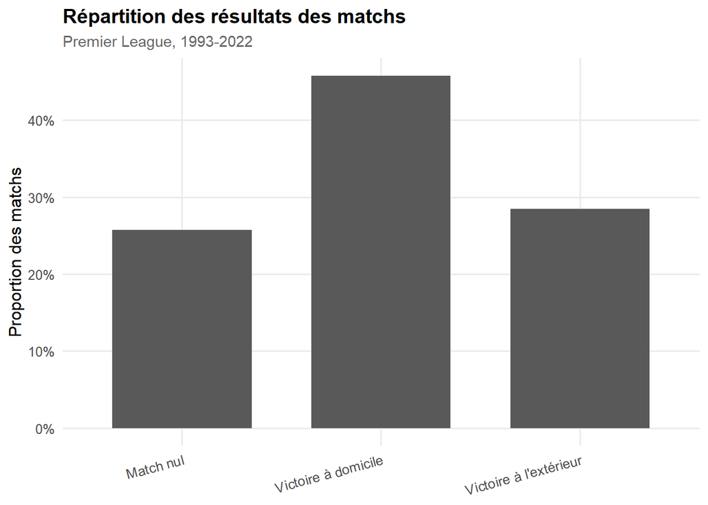

### Analyse des résultats

Ce résultat suggère l’existence d’un avantage du terrain en Premier League : jouer à domicile semble augmenter les chances de victoire.

### Interprétation et limites

Cette analyse met en évidence une tendance générale en faveur des équipes à domicile. Elle confirme donc l’hypothèse de départ.

Cependant, elle ne permet pas d’expliquer précisément les causes de cet avantage. D’autres facteurs, comme le niveau des équipes, la saison, la forme du moment ou l’adversaire rencontré, peuvent aussi influencer les résultats.

## 3. Quelle est la distribution du nombre de buts par match ?

### Hypothèse

Nous cherchons à comprendre comment se distribue le nombre total de buts marqués par match en Premier League.  
On peut supposer que la majorité des matchs comportent un nombre modéré de buts, avec peu de rencontres très riches en buts.

### Choix de la visualisation

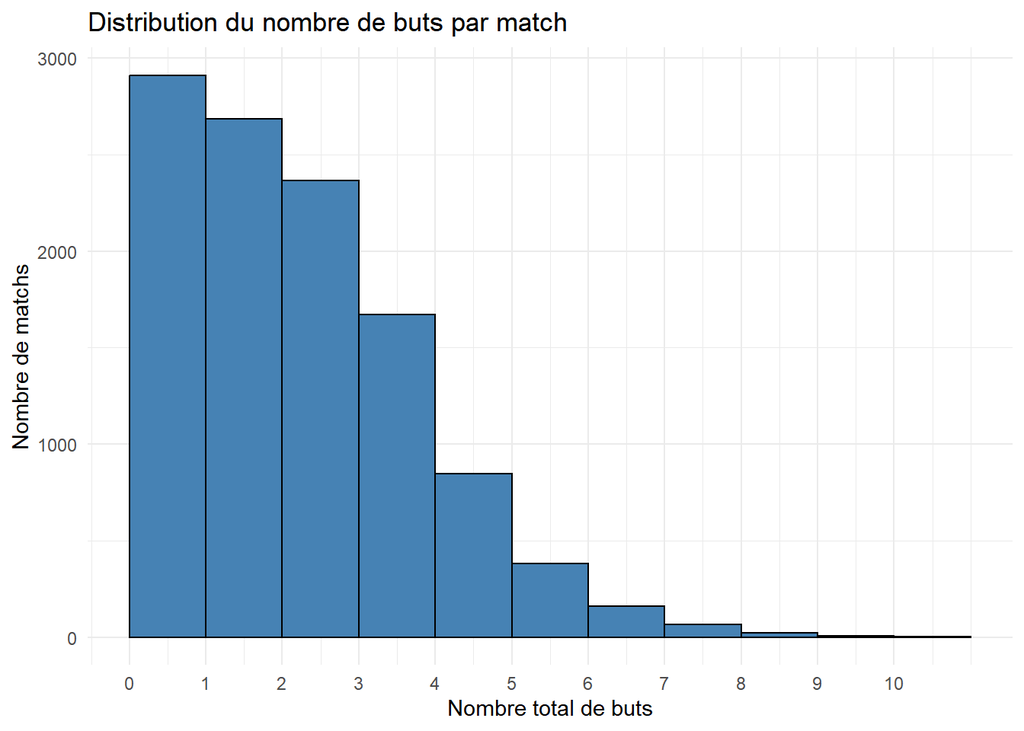

### Analyse des résultats

L’histogramme montre que la majorité des matchs se concentrent entre 1 et 3 buts.

On observe une diminution progressive du nombre de matchs lorsque le nombre total de buts augmente, ce qui indique que les rencontres très riches en buts restent rares.

La distribution est asymétrique à droite, avec quelques valeurs élevées mais peu fréquentes.

Ainsi, le graphique confirme notre hypothèse initiale : les matchs de Premier League présentent généralement un nombre modéré de buts.

### Interprétation et limites

Cette analyse permet de décrire la distribution générale du nombre de buts par match. Cependant, elle ne permet pas d’expliquer pourquoi certains matchs sont plus riches en buts que d’autres.

Pour aller plus loin, il serait utile de croiser le nombre de buts avec d’autres variables, comme les équipes, les saisons ou le nombre de tirs.

## 4. Quelles équipes marquent le plus de buts ?

### Hypothèse

Nous supposons que les équipes historiques du “Big Six” : *Arsenal, Chelsea, Liverpool, Manchester City, Manchester United, Tottenham Hotspur* dominent largement ce classement.

### Choix de la visualisation

Pour comparer des catégories : noms des équipes en fonction d’une valeur numérique : total de buts, le diagramme en barres horizontales est la solution la plus adaptée pour les raisons suivantes :

- **Lisibilité** : compte tenu du grand nombre d’équipes en Premier League, les noms seraient illisibles ou se chevaucheraient sur un axe horizontal (X) alors que l’orientation horizontale permet une lecture naturelle des noms de gauche à droite.
- **Optimisation du tri** : les barres sont triées de la plus grande à la plus petite et selon les principes du cours, un graphique trié réduit la charge cognitive du lecteur en lui permettant d’identifier immédiatement la hiérarchie et les extrêmes.
- **Comparaison directe** : cette représentation facilite la comparaison visuelle des longueurs de barres, mettant en évidence l’écart entre les leaders et le reste du classement.

On se limite au top 15 pour une meilleure lisibilité.

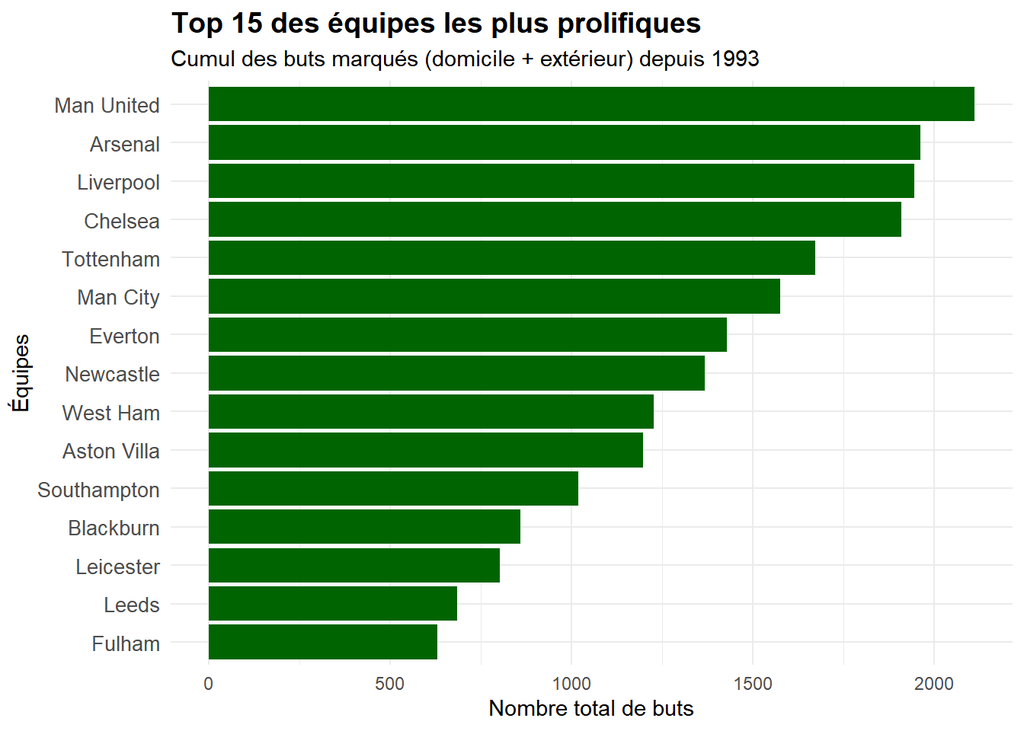

### Analyse des résultats

Le graphique confirme la domination des clubs du “*Big Six*”. Manchester United, Arsenal et Liverpool occupent les trois premières marches du podium.

On observe un écrat marqué entre ces leaders historiques et le reste des équipes : seules les équipes de ce haut de tableau ont inscrits un nombre de buts suprieur à 1500 buts sur la période. Cette visualisation met en évidence une hiérarchie offensive très stable sur le long terme dans le championnat anglais.

### Interprétation et limites

Bien que ce graphique offre une vision globale efficace, il comporte certains biais qu’il est nécessaire de souligner :

- **Biais de longévité** : en utilisant le cumul historique des buts, nous favorisons les équipes n’ayant jamais été reléguées; une équipe très offensive présente seulement 2 ou 3 saisons en Premier League paraîtra moins “prolifique” qu’une équipe moyenne présente depuis 30 ans.
- **Normalisation (Lie Factor)** : pour une analyse plus “honnête” statistiquement, il serait pertinent de comparer ces données avec la moyenne de buts par match. Cela permettrait de minimiser l’effet du temps et d’identifier les équipes réellement qui sont à craindre devant le but.
- **Respect du Data-to-Ink ratio** : nous avons choisi un diagramme à barres horizontales pour garantir la lisibilité des noms de clubs; l’utilisation d’une couleur unique *vert foncé* sans gradients pour ne pas distraire l’œil des valeurs réelles
- **Absence de dynamique temporelle** : le graphique fige une période de 30 ans en une seule barre mais ne permet pas de voir si une équipe est en déclin offensif ou en pleine ascension sur les dernières saisons.

## 5. Les matchs sont-ils souvent décidés en seconde mi-temps ?

### Hypothèse

Nous supposons que la seconde mi-temps joue un rôle important dans l’issue des matchs. Après la pause, les équipes peuvent modifier leur stratégie, la fatigue apparaît et les changements de joueurs peuvent influencer le jeu.

On peut donc s’attendre à observer une proportion importante de matchs dont le résultat évolue entre la mi-temps et la fin du match.

### Choix de la visualisation

Pour répondre à cette question, nous comparons le résultat à la mi-temps (`HTR`) avec le résultat final (`FTR`).

Nous créons une variable `Decision` avec deux catégories :

- `Résultat inchangé` : le résultat à la mi-temps est le même que le résultat final ;
- `Résultat changé en 2e mi-temps` : le résultat final est différent du résultat à la mi-temps.

Nous utilisons ensuite un diagramme en barres afin de comparer la proportion de matchs dans chaque catégorie. Cette visualisation permet de voir rapidement si les changements de résultat après la mi-temps sont fréquents.

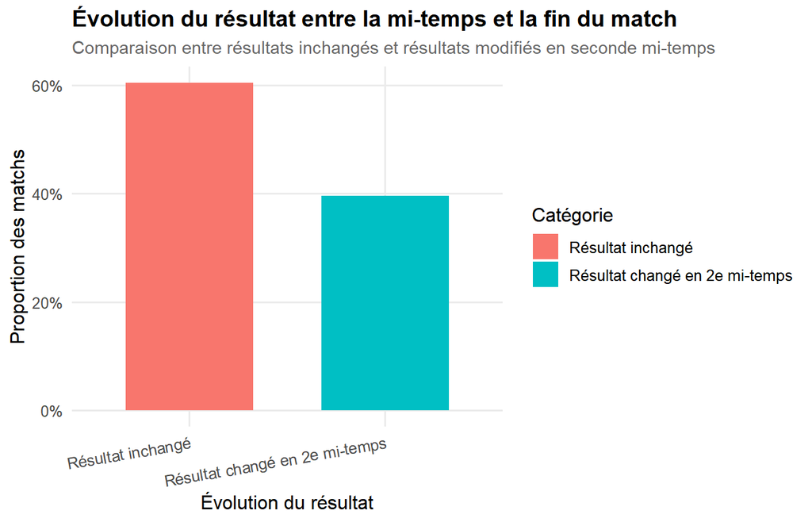

### Analyse des résultats

Le graphique montre que la majorité des matchs conservent le même résultat entre la mi-temps et la fin du match. Environ 61 % des matchs ont un résultat inchangé, contre environ 39 % dont le résultat change en seconde mi-temps.

Ces résultats indiquent que les matchs ne sont pas majoritairement décidés en seconde mi-temps. Cependant, la proportion de changements reste importante : près de quatre matchs sur dix connaissent une évolution du résultat après la pause.

### Interprétation et limites

L’hypothèse de départ n’est donc que partiellement vérifiée. La première mi-temps semble déjà jouer un rôle important dans l’issue du match, car plus de la moitié des matchs gardent le même résultat jusqu’à la fin.

Cependant, cette analyse reste limitée. Elle compare seulement le type de résultat (`H`, `D`, `A`) entre la mi-temps et la fin du match. Elle ne prend pas en compte l’évolution du score exact. Par exemple, un match nul 0-0 à la mi-temps et 2-2 à la fin est considéré comme un résultat inchangé, alors que la seconde mi-temps a été très active.

Cette visualisation permet donc d’étudier les changements d’issue du match, mais elle ne décrit pas toute la dynamique réelle de la seconde mi-temps.

## 6. Quelle proportion de matchs connaît un retournement ?

### Hypothèse

Nous supposons que les retournements complets sont rares en Premier League. Une équipe qui mène à la mi-temps conserve souvent un avantage important jusqu’à la fin du match.

### Choix de la visualisation

Nous utilisons un diagramme en anneau afin de représenter la part des matchs avec retournement complet dans l’ensemble des matchs. Ce choix est adapté car la question porte principalement sur une proportion globale.

Dans cette analyse, un retournement complet correspond aux situations où l’équipe qui mène à la mi-temps perd finalement le match : `HTR = H` et `FTR = A`, ou `HTR = A` et `FTR = H`.

Les matchs passant d’un score nul à une victoire ne sont donc pas considérés ici comme des retournements complets.

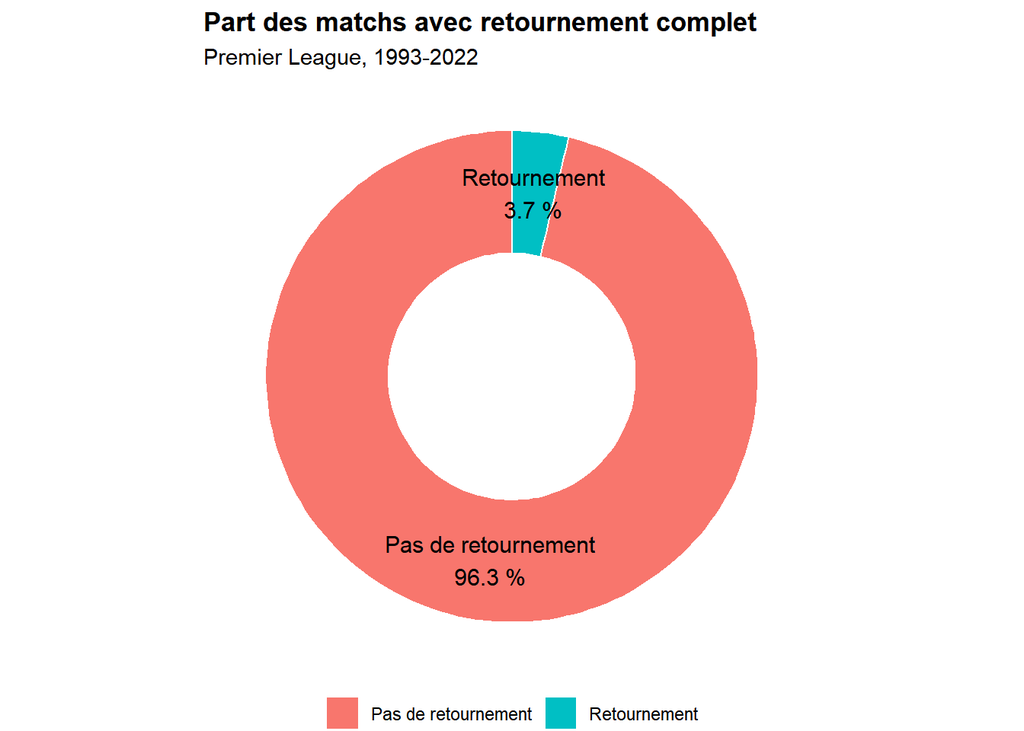

### Analyse des résultats

Le diagramme montre que les retournements complets représentent une faible part des matchs étudiés. La majorité des rencontres ne connaît donc pas de renversement total entre la mi-temps et le résultat final.

Ce résultat confirme l’hypothèse : le fait de mener à la mi-temps constitue généralement un avantage important pour l’issue du match.

### Interprétation et limites

Cette analyse repose uniquement sur le résultat à la mi-temps et le résultat final. Elle ne prend pas en compte le moment exact des buts, les cartons rouges, les blessures ou les changements tactiques.

De plus, les matchs qui passent d’un score nul à une victoire peuvent aussi être décisifs, mais ils ne sont pas considérés ici comme des retournements complets.

## 7. Le résultat à la mi-temps prédit-il le résultat final ?

### Hypothèse

Nous supposons que le résultat à la mi-temps est fortement lié au résultat final. Une équipe qui mène à la pause a plus de chances de gagner le match.

### Choix de la visualisation

Nous utilisons une heatmap pour croiser le résultat à la mi-temps et le résultat final. Cette visualisation permet d’identifier rapidement les situations les plus fréquentes.

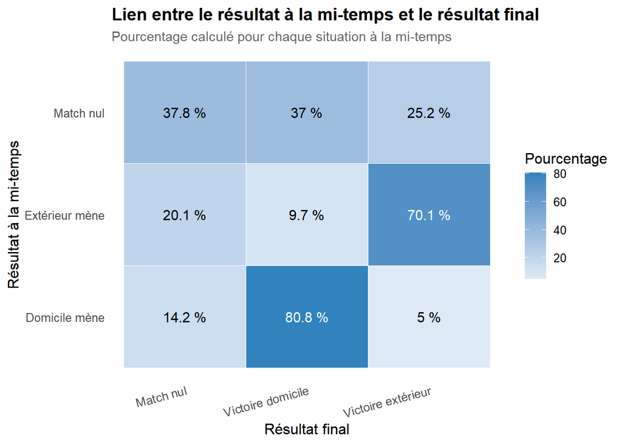

### Analyse des résultats

La heatmap montre que le résultat à la mi-temps est fortement lié au résultat final. Lorsqu’une équipe mène à la pause, elle conserve souvent son avantage jusqu’à la fin du match.

En revanche, les matchs nuls à la mi-temps donnent des résultats plus variés. Le résultat à la pause constitue donc un bon indicateur de l’issue du match, sans permettre une prédiction parfaite.

### Interprétation et limites

Cette analyse met en évidence une tendance générale, mais elle ne prend pas en compte d’autres facteurs, comme les buts en seconde période, les cartons rouges, les blessures ou les changements tactiques.

## 8. La différence de tirs entre les deux équipes est-elle associée au résultat final ?

### Hypothèse

Nous supposons que la différence de tirs entre les deux équipes est liée au résultat final du match. Plus une équipe tire davantage que son adversaire, plus elle devrait avoir de chances de gagner. Cependant, cette relation n’est pas forcément automatique, car le nombre de tirs ne prend pas en compte la qualité des occasions.

### Choix de la visualisation

Pour répondre à cette question, nous utilisons un diagramme en barres empilées à 100 %. Ce type de visualisation permet de comparer la répartition des résultats finaux selon plusieurs niveaux de différence de tirs.

Nous calculons d’abord la variable `ShotDiff` :

```r
ShotDiff = HS - AS
```

Lorsque `ShotDiff` est positif, cela signifie que l’équipe à domicile a tiré plus que l’équipe à l’extérieur. Lorsque `ShotDiff` est négatif, cela signifie que l’équipe à l’extérieur a tiré plus que l’équipe à domicile. Lorsque `ShotDiff` est égal à 0, les deux équipes ont tiré autant.

Nous regroupons ensuite les matchs en cinq catégories :

```
Avantage extérieur fort
Avantage extérieur léger
Égalité
Avantage domicile léger
Avantage domicile fort
```

Cette représentation permet d’observer si la proportion de victoires évolue lorsque l’écart de tirs devient plus favorable à une équipe.

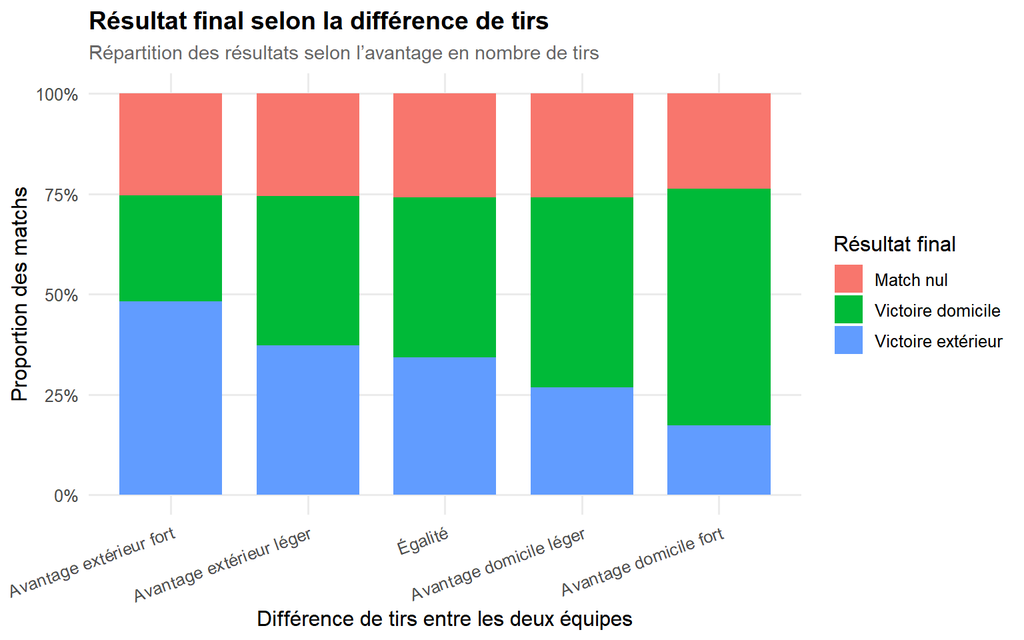

### Analyse des résultats

Le graphique montre une tendance progressive : plus l’avantage en tirs est favorable à l’équipe à domicile, plus la proportion de victoires à domicile augmente. À l’inverse, lorsque l’avantage en tirs est favorable à l’équipe à l’extérieur, les victoires à l’extérieur sont plus fréquentes.

Dans la catégorie « Égalité », les résultats sont plus équilibrés : aucune issue ne domine totalement. Cela suggère que la différence de tirs est bien associée au résultat final, mais qu’elle ne suffit pas à expliquer tous les matchs.

### Interprétation et limites

La domination en nombre de tirs semble donc être un indicateur important du résultat final. Cependant, cette relation n’est pas automatique : même avec un fort avantage en tirs, une équipe peut ne pas gagner.

Cette analyse ne prend pas en compte la qualité des tirs. Un tir cadré, une occasion dangereuse ou un tir lointain sont ici traités de manière trop simple. C’est pourquoi il est nécessaire de compléter cette analyse avec les tirs cadrés et l’efficacité offensive.

## 9. Les tirs cadrés permettent-ils de mieux expliquer le nombre de buts que le nombre total de tirs ?

### Hypothèse

Nous supposons que les tirs cadrés sont plus liés au nombre de buts que le nombre total de tirs. En effet, un tir cadré représente une occasion plus dangereuse qu’un simple tir, car il oblige le gardien ou la défense à intervenir directement.

### Choix de la visualisation

Pour répondre à cette question, nous utilisons un nuage de points comparatif. Cette visualisation permet d’observer la relation entre deux variables numériques : le nombre de tirs et le nombre de buts.

Nous comparons deux relations : d’une part, le nombre total de tirs et le nombre total de buts ; d’autre part, le nombre total de tirs cadrés et le nombre total de buts.

Chaque point représente un match. Une droite de tendance est ajoutée pour visualiser la relation générale. Cela permet de voir si les tirs cadrés semblent mieux associés aux buts que les tirs totaux.

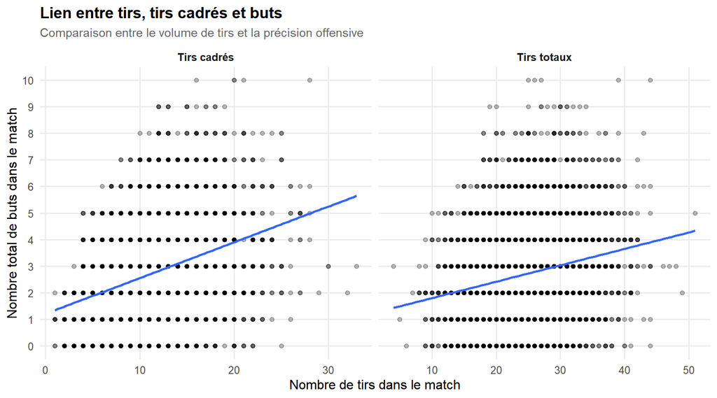

### Analyse des résultats

Les deux graphiques montrent une relation positive entre les tirs et les buts : plus le nombre de tirs augmente, plus le nombre de buts a tendance à augmenter.

Cependant, cette relation est plus nette pour les tirs cadrés. La droite de tendance est plus inclinée dans le graphique des tirs cadrés, ce qui montre que les buts augmentent plus clairement lorsque le nombre de tirs cadrés augmente.

Les tirs totaux donnent donc une information sur le volume offensif, mais les tirs cadrés semblent mieux liés au nombre de buts. Cela suggère que la précision des tirs est plus importante que la simple quantité de tirs.

### Interprétation et limites

Cette analyse montre que les tirs cadrés sont un meilleur indicateur de l’efficacité offensive que les tirs totaux. Une équipe peut beaucoup tirer sans marquer si ses tirs ne sont pas cadrés.

Cependant, cette visualisation ne mesure pas précisément la qualité des occasions. Un tir cadré facile à arrêter et une occasion très dangereuse sont comptés de la même manière. De plus, les tirs des deux équipes sont regroupés au niveau du match, ce qui ne permet pas d’analyser séparément la performance de chaque équipe.

Pour aller plus loin, il serait utile d’étudier les tirs cadrés par équipe ou d’utiliser des indicateurs plus précis comme la position du tir ou les expected goals.

## 13. Les matchs les plus ouverts offensivement sont-ils aussi les plus imprévisibles ?

### Hypothèse

Nous supposons que les matchs avec beaucoup de buts ne sont pas forcément les plus équilibrés. Un match très ouvert peut correspondre à une rencontre spectaculaire et serrée, mais aussi à une large victoire d’une équipe.

### Choix de la visualisation

Nous utilisons un nuage de points afin d’étudier la relation entre le nombre total de buts dans un match et l’écart final au score. Cette visualisation permet de voir si les matchs riches en buts sont plutôt serrés ou déséquilibrés.

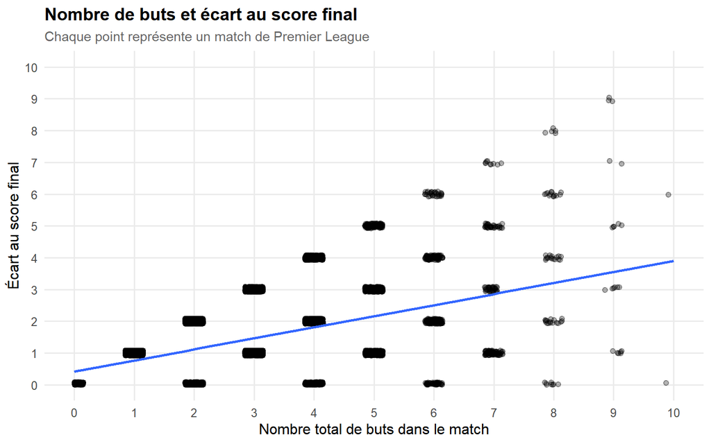

### Analyse des résultats

Le graphique montre que les matchs avec peu de buts présentent souvent un écart au score limité. Cela correspond notamment aux scores serrés comme 0-0, 1-0 ou 1-1.

Lorsque le nombre total de buts augmente, l’écart au score peut aussi augmenter. Cela montre que les matchs les plus ouverts ne sont pas toujours les plus imprévisibles : certains sont spectaculaires mais restent déséquilibrés.

### Critiques et limites

Cette analyse mesure l’équilibre d’un match uniquement avec l’écart final au score. Elle ne permet pas de savoir si le match a réellement été disputé pendant toute sa durée.

De plus, un score final serré ne signifie pas forcément que les deux équipes ont eu le même niveau de domination. Des variables comme les tirs, les tirs cadrés ou la possession permettraient de compléter l’analyse.

## 14. Comment l’efficacité (Buts/Tirs) varie-t-elle selon les 5 meilleures équipes ?

### Hypothèse

Nous supposons que les meilleures équipes ne sont pas seulement celles qui tirent beaucoup, mais aussi celles qui convertissent efficacement leurs tirs en buts. Une équipe très performante offensivement devrait donc présenter un ratio buts/tirs plus élevé que les autres.

### Choix de la visualisation

Cette visualisation permet de comparer séparément les profils des équipes sélectionnées. L’efficacité est mesurée par le ratio entre le nombre de buts marqués et le nombre de tirs effectués. Plus ce ratio est élevé, plus l’équipe transforme efficacement ses tirs en buts.

[figure not shown]

### Analyse des résultats

Une équipe avec un ratio buts/tirs plus élevé apparaît plus efficace, car elle marque davantage par rapport au nombre de tirs tentés. À l’inverse, une équipe avec un ratio plus faible peut rester très prolifique grâce à un volume de tirs important, mais être moins efficace dans la conversion de ses occasions.

Cette analyse permet donc de nuancer le classement des meilleures attaques. Marquer beaucoup de buts ne signifie pas nécessairement être l’équipe la plus efficace : certaines équipes peuvent compenser une efficacité plus faible par une production offensive très élevée.

### Critiques et limites

Le ratio buts/tirs donne une indication simple de l’efficacité offensive, mais il ne tient pas compte de la qualité des tirs. Une équipe peut avoir un bon ratio parce qu’elle se crée des occasions très dangereuses, ou parce qu’elle bénéficie de situations particulières comme des penalties.

Enfin, les données sont agrégées sur plusieurs saisons. Les effectifs, les entraîneurs et les styles de jeu des équipes ont pu évoluer au fil du temps, ce qui limite l’interprétation directe des différences observées.

## 16. Existe-t-il une relation entre fautes et cartons ?

### Hypothèse

Nous supposons qu’il existe une relation positive entre le nombre de fautes commises par une équipe et le nombre de cartons qu’elle reçoit. Une équipe qui commet beaucoup de fautes devrait logiquement être plus exposée aux sanctions disciplinaires, même si toutes les fautes ne conduisent pas automatiquement à un carton.

### Choix de la visualisation

Nous utilisons un nuage de points afin d’étudier la relation entre deux variables numériques : le nombre de fautes commises et le nombre de cartons reçus.

Chaque point représente une équipe lors d’un match, qu’elle joue à domicile ou à l’extérieur. L’axe horizontal indique le nombre de fautes commises, tandis que l’axe vertical indique le nombre de cartons reçus. Une droite de tendance est ajoutée afin de visualiser plus clairement la relation générale entre ces deux variables.

Le léger décalage des points permet de limiter leur superposition et de rendre la visualisation plus lisible.

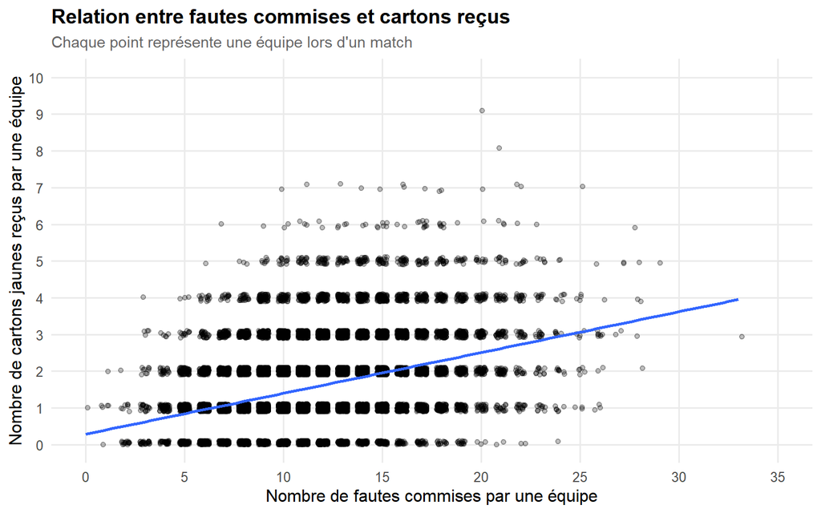

### Analyse des résultats

Le graphique montre une relation positive entre le nombre de fautes commises et le nombre de cartons reçus. Les équipes qui commettent davantage de fautes ont généralement tendance à recevoir plus de cartons.

Toutefois, la dispersion des points montre que cette relation n’est pas parfaite. Pour un même nombre de fautes, certaines équipes reçoivent plus de cartons que d’autres, ce qui suggère que d’autres facteurs interviennent également.

### Interprétation et limites

Cette analyse repose uniquement sur les cartons jaunes et ne prend pas en compte les cartons rouges.

Par ailleurs, toutes les fautes sont comptabilisées de la même manière alors que certaines sont plus sévères que d’autres. Le contexte du match ou les décisions arbitrales peuvent également influencer le nombre de cartons distribués.

## 17. Les arbitres sanctionnent-ils de la même manière un nombre donné de fautes ?

### Hypothèse

Nous supposons qu’à nombre de fautes comparable, certains arbitres distribuent davantage de cartons que d’autres. Cela pourrait traduire des différences dans leur manière de sanctionner les rencontres.

### Choix de la visualisation

Nous utilisons un nuage de points afin de comparer, pour chaque arbitre, le nombre moyen de fautes observées et le nombre moyen de cartons distribués. Cette visualisation permet de voir si les arbitres qui dirigent des matchs plus fautifs distribuent aussi davantage de cartons.

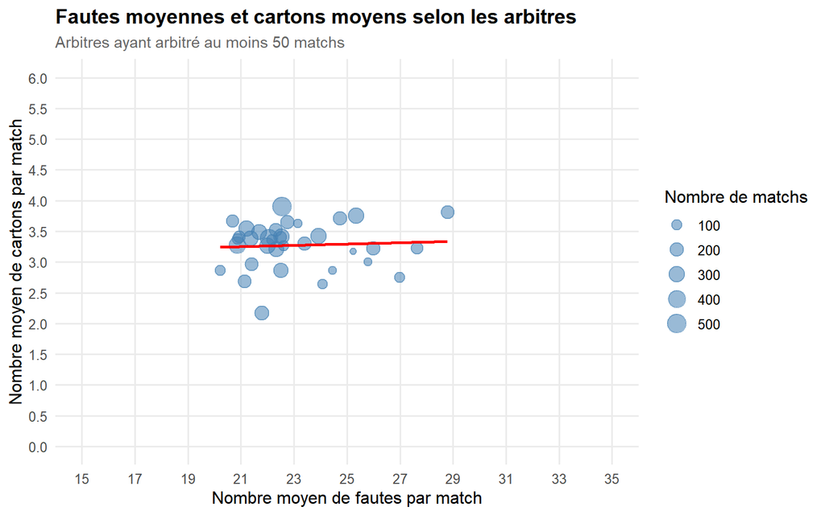

### Critiques et limites

Cette analyse repose sur des moyennes par arbitre, ce qui peut masquer des différences importantes entre les matchs.

De plus, le graphique ne prend pas en compte la gravité des fautes ni le contexte des rencontres. Un même nombre de fautes peut donc conduire à un nombre de cartons différent selon la nature du match.

## 18. Certaines équipes sont-elles plus sanctionnées que d’autres ?

### Hypothèse

Nous supposons que certaines équipes reçoivent davantage de cartons que d’autres. Ces différences peuvent être liées au style de jeu, au niveau d’agressivité, à la stratégie défensive ou encore à la fréquence des situations de pression subies pendant les matchs.

### Choix de la visualisation

Nous utilisons un diagramme en barres horizontal afin de comparer le nombre moyen de cartons reçus par match selon les équipes.

Pour rendre le graphique lisible, nous affichons uniquement les 15 équipes les plus sanctionnées en moyenne. Cette visualisation permet d’identifier rapidement les équipes qui se distinguent par un niveau de sanction plus élevé.

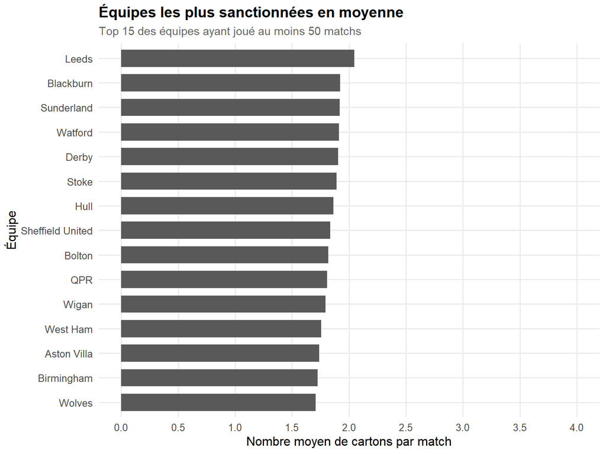

## 19. Les arbitres distribuent-ils différemment les cartons ?

### Hypothèse

Nous supposons que le nombre de cartons distribués peut varier selon les arbitres. Certains arbitres peuvent avoir tendance à sanctionner plus fréquemment les fautes, tandis que d’autres peuvent laisser davantage jouer. Cette différence pourrait se traduire par un nombre moyen de cartons par match plus élevé chez certains arbitres.

### Choix de la visualisation

Nous utilisons un diagramme en barres horizontal afin de comparer le nombre moyen de cartons distribués par match selon les arbitres. Cette visualisation est adaptée car elle permet de comparer clairement plusieurs catégories, ici les arbitres, à partir d’une mesure numérique.

Pour rendre le graphique lisible, nous conservons uniquement les arbitres ayant dirigé au moins 50 matchs dans le dataset. Ce choix évite de comparer des arbitres présents sur très peu de rencontres, dont la moyenne pourrait être moins représentative.

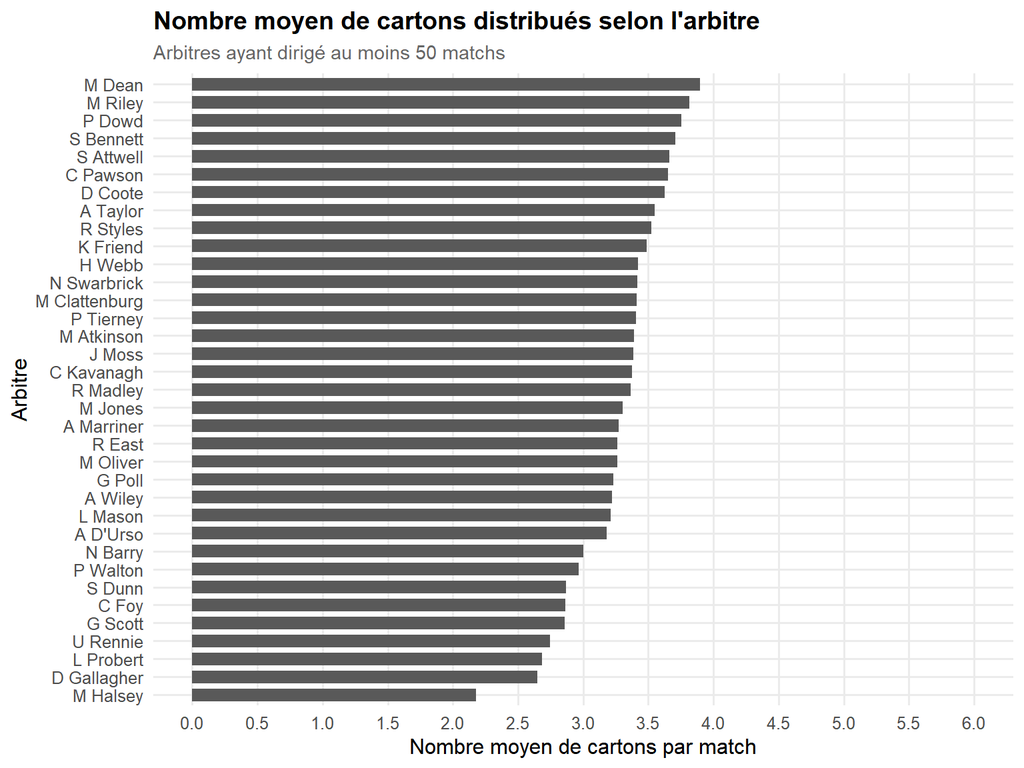

### Analyse des résultats

Le graphique montre que le nombre moyen de cartons distribués varie selon les arbitres. Certains arbitres distribuent en moyenne davantage de cartons que d’autres.

Les écarts observés restent cependant relativement modérés. Cela suggère que les arbitres n’ont pas exactement les mêmes habitudes de sanction, même si leurs comportements restent globalement comparables.

### Interprétation et limites

Cette analyse repose sur une moyenne de cartons par match, ce qui ne permet pas de prendre en compte la variabilité entre les rencontres.

De plus, le nombre de cartons peut dépendre du style de jeu des équipes ou du contexte du match, et pas uniquement de l’arbitre lui-même.

## 20.Le nombre de buts évolue-t-il selon les saisons ?

### Hypothèse

Nous cherchons à savoir si le nombre moyen de buts marqués par match évolue au fil des saisons de Premier League.

On peut supposer que certaines saisons sont plus offensives que d’autres, ce qui pourrait se traduire par des variations du nombre moyen de buts.

### Choix de la visualisation

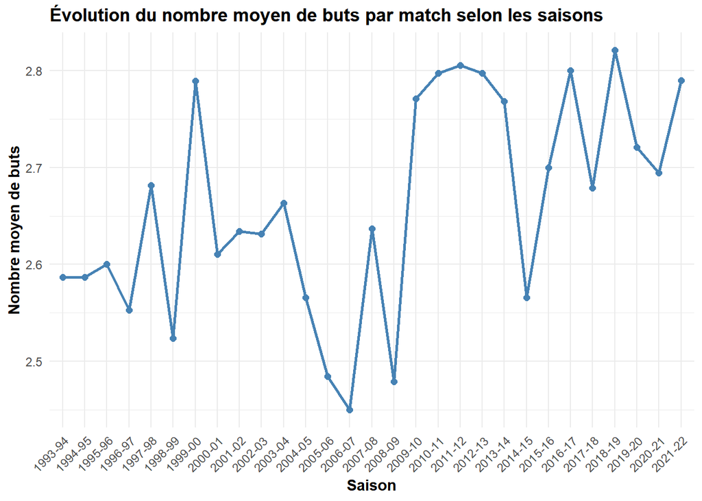

### Analyse des résultats

Le graphique montre l’évolution du nombre moyen de buts par match au fil des saisons de Premier League.

On observe que cette moyenne reste globalement assez stable, généralement autour de 2,5 à 2,8 buts par match. Cela signifie que la plupart des saisons présentent en moyenne entre deux et trois buts par rencontre.

Cependant, certaines fluctuations apparaissent selon les saisons. On remarque par exemple une baisse autour des saisons 2005-2008, puis une remontée progressive après 2010. Ces variations montrent que le nombre moyen de buts n’est pas parfaitement constant d’une saison à l’autre.

Dans les saisons les plus récentes, la moyenne semble légèrement plus élevée qu’au milieu des années 2000. Cela suggère une tendance modérée à l’augmentation du nombre de buts, même si cette évolution reste limitée.

### Interprétation et limites

Ces résultats indiquent que le nombre de buts par match en Premier League reste relativement stable sur l’ensemble de la période étudiée, avec quelques variations selon les saisons.

Il faut cependant rester prudent dans l’interprétation. Le graphique permet d’observer une évolution du nombre de buts, mais il ne permet pas d’expliquer directement les causes de ces variations. Celles-ci peuvent être liées à de nombreux facteurs, comme les styles de jeu, le niveau des équipes, les changements tactiques ou encore l’évolution du championnat.

Ainsi, on peut parler d’une légère tendance à la hausse dans les saisons récentes, mais il serait nécessaire d’analyser d’autres variables pour confirmer l’idée d’un championnat plus offensif ou plus spectaculaire.